# Задача

Проанализировать массив данных (http://archive.ics.uci.edu/ml/datasets/Facebook+metrics) при помощи языка Python (допускается и рекомендуется использование дополнительных библиотек): вычисление среднего, максимального/минимального значений, медианы, моды числовых значений как для всего массива в целом, так и для каждого типа контента (столбец Type) в отдельности. Найти самый популярный объект в выборке, объяснить почему. Решение предоставить в виде .py/.ipynb файла.

```python
# Python 2 and 3 compatibility
from __future__ import (absolute_import, division,
                        print_function, unicode_literals)
# отключим предупреждения Anaconda
import warnings
warnings.simplefilter('ignore')
import pandas as pd
%pylab inline
import matplotlib.pyplot as plt
```

# Загружаем и изучаем данные

```python
df = pd.read_csv('dataset_Facebook.csv', delimiter=';')
df.shape
```

```
(500, 19)
```

```python
df.head()
```

|  | Page total likes | Type | Category | Post Month | Post Weekday | Post Hour | Paid | Lifetime Post Total Reach | Lifetime Post Total Impressions | Lifetime Engaged Users | Lifetime Post Consumers | Lifetime Post Consumptions | Lifetime Post Impressions by people who have liked your Page | Lifetime Post reach by people who like your Page | Lifetime People who have liked your Page and engaged with your post | comment | like | share | Total Interactions |
| --- | --- | --- | --- | --- | --- | --- | --- | --- | --- | --- | --- | --- | --- | --- | --- | --- | --- | --- | --- |
| 0 | 139441 | Photo | 2 | 12 | 4 | 3 | 0.0 | 2752 | 5091 | 178 | 109 | 159 | 3078 | 1640 | 119 | 4 | 79.0 | 17.0 | 100 |
| 1 | 139441 | Status | 2 | 12 | 3 | 10 | 0.0 | 10460 | 19057 | 1457 | 1361 | 1674 | 11710 | 6112 | 1108 | 5 | 130.0 | 29.0 | 164 |
| 2 | 139441 | Photo | 3 | 12 | 3 | 3 | 0.0 | 2413 | 4373 | 177 | 113 | 154 | 2812 | 1503 | 132 | 0 | 66.0 | 14.0 | 80 |
| 3 | 139441 | Photo | 2 | 12 | 2 | 10 | 1.0 | 50128 | 87991 | 2211 | 790 | 1119 | 61027 | 32048 | 1386 | 58 | 1572.0 | 147.0 | 1777 |
| 4 | 139441 | Photo | 2 | 12 | 2 | 3 | 0.0 | 7244 | 13594 | 671 | 410 | 580 | 6228 | 3200 | 396 | 19 | 325.0 | 49.0 | 393 |

```python
df.describe()
```

|  | Page total likes | Category | Post Month | Post Weekday | Post Hour | Paid | Lifetime Post Total Reach | Lifetime Post Total Impressions | Lifetime Engaged Users | Lifetime Post Consumers | Lifetime Post Consumptions | Lifetime Post Impressions by people who have liked your Page | Lifetime Post reach by people who like your Page | Lifetime People who have liked your Page and engaged with your post | comment | like | share | Total Interactions |
| --- | --- | --- | --- | --- | --- | --- | --- | --- | --- | --- | --- | --- | --- | --- | --- | --- | --- | --- |
| count | 500.000000 | 500.000000 | 500.000000 | 500.000000 | 500.000000 | 499.000000 | 500.00000 | 5.000000e+02 | 500.000000 | 500.000000 | 500.000000 | 5.000000e+02 | 500.000000 | 500.000000 | 500.00000 | 499.000000 | 496.000000 | 500.000000 |
| mean | 123194.176000 | 1.880000 | 7.038000 | 4.150000 | 7.840000 | 0.278557 | 13903.36000 | 2.958595e+04 | 920.344000 | 798.772000 | 1415.130000 | 1.676638e+04 | 6585.488000 | 609.986000 | 7.48200 | 177.945892 | 27.266129 | 212.120000 |
| std | 16272.813214 | 0.852675 | 3.307936 | 2.030701 | 4.368589 | 0.448739 | 22740.78789 | 7.680325e+04 | 985.016636 | 882.505013 | 2000.594118 | 5.979102e+04 | 7682.009405 | 612.725618 | 21.18091 | 323.398742 | 42.613292 | 380.233118 |
| min | 81370.000000 | 1.000000 | 1.000000 | 1.000000 | 1.000000 | 0.000000 | 238.00000 | 5.700000e+02 | 9.000000 | 9.000000 | 9.000000 | 5.670000e+02 | 236.000000 | 9.000000 | 0.00000 | 0.000000 | 0.000000 | 0.000000 |
| 25% | 112676.000000 | 1.000000 | 4.000000 | 2.000000 | 3.000000 | 0.000000 | 3315.00000 | 5.694750e+03 | 393.750000 | 332.500000 | 509.250000 | 3.969750e+03 | 2181.500000 | 291.000000 | 1.00000 | 56.500000 | 10.000000 | 71.000000 |
| 50% | 129600.000000 | 2.000000 | 7.000000 | 4.000000 | 9.000000 | 0.000000 | 5281.00000 | 9.051000e+03 | 625.500000 | 551.500000 | 851.000000 | 6.255500e+03 | 3417.000000 | 412.000000 | 3.00000 | 101.000000 | 19.000000 | 123.500000 |
| 75% | 136393.000000 | 3.000000 | 10.000000 | 6.000000 | 11.000000 | 1.000000 | 13168.00000 | 2.208550e+04 | 1062.000000 | 955.500000 | 1463.000000 | 1.486050e+04 | 7989.000000 | 656.250000 | 7.00000 | 187.500000 | 32.250000 | 228.500000 |
| max | 139441.000000 | 3.000000 | 12.000000 | 7.000000 | 23.000000 | 1.000000 | 180480.00000 | 1.110282e+06 | 11452.000000 | 11328.000000 | 19779.000000 | 1.107833e+06 | 51456.000000 | 4376.000000 | 372.00000 | 5172.000000 | 790.000000 | 6334.000000 |

# вычисление среднего, максимального/минимального значений, медианы, моды

# - для всего массива в целом

```python
modes = df.mode().drop('Type', axis=1).iloc[0]
```

```python
df.describe(percentiles=[]).drop(['count', 'std'], axis=0).append(modes).rename(index={"50%": "median", 0: "mode"})
```

|  | Page total likes | Category | Post Month | Post Weekday | Post Hour | Paid | Lifetime Post Total Reach | Lifetime Post Total Impressions | Lifetime Engaged Users | Lifetime Post Consumers | Lifetime Post Consumptions | Lifetime Post Impressions by people who have liked your Page | Lifetime Post reach by people who like your Page | Lifetime People who have liked your Page and engaged with your post | comment | like | share | Total Interactions |
| --- | --- | --- | --- | --- | --- | --- | --- | --- | --- | --- | --- | --- | --- | --- | --- | --- | --- | --- |
| mean | 123194.176 | 1.88 | 7.038 | 4.15 | 7.84 | 0.278557 | 13903.36 | 29585.948 | 920.344 | 798.772 | 1415.13 | 16766.376 | 6585.488 | 609.986 | 7.482 | 177.945892 | 27.266129 | 212.12 |
| min | 81370.000 | 1.00 | 1.000 | 1.00 | 1.00 | 0.000000 | 238.00 | 570.000 | 9.000 | 9.000 | 9.00 | 567.000 | 236.000 | 9.000 | 0.000 | 0.000000 | 0.000000 | 0.00 |
| median | 129600.000 | 2.00 | 7.000 | 4.00 | 9.00 | 0.000000 | 5281.00 | 9051.000 | 625.500 | 551.500 | 851.00 | 6255.500 | 3417.000 | 412.000 | 3.000 | 101.000000 | 19.000000 | 123.50 |
| max | 139441.000 | 3.00 | 12.000 | 7.00 | 23.00 | 1.000000 | 180480.00 | 1110282.000 | 11452.000 | 11328.000 | 19779.00 | 1107833.000 | 51456.000 | 4376.000 | 372.000 | 5172.000000 | 790.000000 | 6334.00 |
| mode | 136393.000 | 1.00 | 10.000 | 7.00 | 3.00 | 0.000000 | 677.00 | 4372.000 | 537.000 | 182.000 | 431.00 | 1210.000 | 690.000 | 403.000 | 0.000 | 98.000000 | 13.000000 | 0.00 |

# - для каждого типа контента в отдельности

```python
list(df['Type'].value_counts().index)
```

```
['Photo', 'Status', 'Link', 'Video']
```

```python
def ByType(type_):
    modes = df[df['Type']==type_].mode().drop('Type', axis=1).iloc[0]
    return df[df['Type']==type_].describe(percentiles=[]).drop(['count', 'std'], axis=0).append(modes).rename(index={"50%": "median", 0: "mode"})
```

```python
ByType('Photo')
```

|  | Page total likes | Category | Post Month | Post Weekday | Post Hour | Paid | Lifetime Post Total Reach | Lifetime Post Total Impressions | Lifetime Engaged Users | Lifetime Post Consumers | Lifetime Post Consumptions | Lifetime Post Impressions by people who have liked your Page | Lifetime Post reach by people who like your Page | Lifetime People who have liked your Page and engaged with your post | comment | like | share | Total Interactions |
| --- | --- | --- | --- | --- | --- | --- | --- | --- | --- | --- | --- | --- | --- | --- | --- | --- | --- | --- |
| mean | 122354.171362 | 1.91784 | 6.805164 | 4.107981 | 7.997653 | 0.28 | 13137.814554 | 2.899450e+04 | 818.946009 | 690.431925 | 1299.025822 | 1.642248e+04 | 6059.103286 | 507.305164 | 7.492958 | 182.611765 | 27.158768 | 216.579812 |
| min | 81370.000000 | 1.00000 | 1.000000 | 1.000000 | 1.000000 | 0.00 | 238.000000 | 5.700000e+02 | 9.000000 | 9.000000 | 9.000000 | 5.670000e+02 | 236.000000 | 9.000000 | 0.000000 | 0.000000 | 0.000000 | 0.000000 |
| median | 128032.000000 | 2.00000 | 7.000000 | 4.000000 | 9.000000 | 0.00 | 4675.000000 | 8.118500e+03 | 605.500000 | 528.500000 | 827.000000 | 5.498000e+03 | 3110.000000 | 403.000000 | 3.000000 | 100.000000 | 19.000000 | 122.000000 |
| max | 139441.000000 | 3.00000 | 12.000000 | 7.000000 | 23.000000 | 1.00 | 180480.000000 | 1.110282e+06 | 11452.000000 | 11328.000000 | 19779.000000 | 1.107833e+06 | 51456.000000 | 3430.000000 | 372.000000 | 5172.000000 | 790.000000 | 6334.000000 |
| mode | 124940.000000 | 1.00000 | 10.000000 | 7.000000 | 3.000000 | 0.00 | 677.000000 | 4.372000e+03 | 537.000000 | 298.000000 | 431.000000 | 1.210000e+03 | 690.000000 | 403.000000 | 0.000000 | 7.000000 | 14.000000 | 0.000000 |

```python
ByType('Status')
```

|  | Page total likes | Category | Post Month | Post Weekday | Post Hour | Paid | Lifetime Post Total Reach | Lifetime Post Total Impressions | Lifetime Engaged Users | Lifetime Post Consumers | Lifetime Post Consumptions | Lifetime Post Impressions by people who have liked your Page | Lifetime Post reach by people who like your Page | Lifetime People who have liked your Page and engaged with your post | comment | like | share | Total Interactions |
| --- | --- | --- | --- | --- | --- | --- | --- | --- | --- | --- | --- | --- | --- | --- | --- | --- | --- | --- |
| mean | 132647.044444 | 2.022222 | 9.066667 | 4.577778 | 7.244444 | 0.222222 | 13078.888889 | 24244.466667 | 2040.222222 | 1949.555556 | 2838.866667 | 18664.266667 | 9908.577778 | 1719.844444 | 8.911111 | 176.711111 | 31.422222 | 217.044444 |
| min | 104070.000000 | 1.000000 | 3.000000 | 1.000000 | 2.000000 | 0.000000 | 3930.000000 | 7509.000000 | 128.000000 | 86.000000 | 112.000000 | 5009.000000 | 2410.000000 | 101.000000 | 0.000000 | 13.000000 | 1.000000 | 17.000000 |
| median | 135713.000000 | 2.000000 | 10.000000 | 5.000000 | 9.000000 | 0.000000 | 11096.000000 | 20849.000000 | 1701.000000 | 1599.000000 | 2201.000000 | 17502.000000 | 8980.000000 | 1604.000000 | 4.000000 | 150.000000 | 28.000000 | 186.000000 |
| max | 139441.000000 | 3.000000 | 12.000000 | 7.000000 | 15.000000 | 1.000000 | 31136.000000 | 59964.000000 | 6164.000000 | 5934.000000 | 9237.000000 | 37849.000000 | 21352.000000 | 4376.000000 | 60.000000 | 859.000000 | 123.000000 | 1009.000000 |
| mode | 139441.000000 | 2.000000 | 12.000000 | 5.000000 | 10.000000 | 0.000000 | NaN | NaN | NaN | NaN | 1692.000000 | NaN | NaN | NaN | 2.000000 | 86.000000 | 1.000000 | 117.000000 |

```python
ByType('Link')
```

|  | Page total likes | Category | Post Month | Post Weekday | Post Hour | Paid | Lifetime Post Total Reach | Lifetime Post Total Impressions | Lifetime Engaged Users | Lifetime Post Consumers | Lifetime Post Consumptions | Lifetime Post Impressions by people who have liked your Page | Lifetime Post reach by people who like your Page | Lifetime People who have liked your Page and engaged with your post | comment | like | share | Total Interactions |
| --- | --- | --- | --- | --- | --- | --- | --- | --- | --- | --- | --- | --- | --- | --- | --- | --- | --- | --- |
| mean | 116363.181818 | 1.136364 | 6.590909 | 4.272727 | 5.727273 | 0.272727 | 18544.590909 | 28725.454545 | 342.818182 | 292.681818 | 374.090909 | 11148.590909 | 6544.363636 | 210.545455 | 2.818182 | 73.318182 | 12.909091 | 89.045455 |
| min | 85979.000000 | 1.000000 | 1.000000 | 1.000000 | 2.000000 | 0.000000 | 1536.000000 | 3094.000000 | 24.000000 | 23.000000 | 26.000000 | 2307.000000 | 1180.000000 | 19.000000 | 0.000000 | 5.000000 | 0.000000 | 6.000000 |
| median | 115396.000000 | 1.000000 | 4.500000 | 4.500000 | 4.000000 | 0.000000 | 7422.000000 | 9773.000000 | 244.000000 | 205.000000 | 290.000000 | 9034.500000 | 5039.000000 | 161.500000 | 1.500000 | 37.000000 | 10.500000 | 52.500000 |
| max | 138895.000000 | 3.000000 | 12.000000 | 7.000000 | 14.000000 | 1.000000 | 70912.000000 | 229733.000000 | 1374.000000 | 1106.000000 | 1345.000000 | 42338.000000 | 27232.000000 | 788.000000 | 15.000000 | 379.000000 | 44.000000 | 420.000000 |
| mode | 138353.000000 | 1.000000 | 12.000000 | 6.000000 | 3.000000 | 0.000000 | NaN | NaN | 66.000000 | 322.000000 | NaN | NaN | NaN | NaN | 0.000000 | 12.000000 | 2.000000 | 14.000000 |

```python
ByType('Video')
```

|  | Page total likes | Category | Post Month | Post Weekday | Post Hour | Paid | Lifetime Post Total Reach | Lifetime Post Total Impressions | Lifetime Engaged Users | Lifetime Post Consumers | Lifetime Post Consumptions | Lifetime Post Impressions by people who have liked your Page | Lifetime Post reach by people who like your Page | Lifetime People who have liked your Page and engaged with your post | comment | like | share | Total Interactions |
| --- | --- | --- | --- | --- | --- | --- | --- | --- | --- | --- | --- | --- | --- | --- | --- | --- | --- | --- |
| mean | 135014.857143 | 1.0 | 9.571429 | 3.571429 | 8.714286 | 0.571429 | 51205.714286 | 102622.428571 | 1707.0 | 1584.714286 | 2600.142857 | 43149.857143 | 17386.285714 | 979.428571 | 12.285714 | 231.428571 | 52.142857 | 295.857143 |
| min | 126424.000000 | 1.0 | 6.000000 | 2.000000 | 2.000000 | 0.000000 | 13544.000000 | 30235.000000 | 459.0 | 411.000000 | 539.000000 | 21436.000000 | 9568.000000 | 363.000000 | 2.000000 | 65.000000 | 13.000000 | 81.000000 |
| median | 137893.000000 | 1.0 | 11.000000 | 3.000000 | 11.000000 | 1.000000 | 30624.000000 | 56950.000000 | 1779.0 | 1643.000000 | 2331.000000 | 30131.000000 | 14112.000000 | 885.000000 | 17.000000 | 204.000000 | 44.000000 | 271.000000 |
| max | 138895.000000 | 1.0 | 12.000000 | 6.000000 | 13.000000 | 1.000000 | 139008.000000 | 277100.000000 | 3872.0 | 3822.000000 | 7327.000000 | 107502.000000 | 38720.000000 | 2218.000000 | 23.000000 | 449.000000 | 121.000000 | 550.000000 |
| mode | 137893.000000 | 1.0 | 11.000000 | 2.000000 | 11.000000 | 1.000000 | NaN | NaN | NaN | NaN | NaN | NaN | NaN | NaN | 2.000000 | NaN | 13.000000 | NaN |

# Найти самый популярный объект в выборке, объяснить почему.

### По какому параметру определять популярность?

```python
popular = ['comment', 'like', 'share', 'Total Interactions']
```

```python
df[popular].max()
```

```
comment                372.0
like                  5172.0
share                  790.0
Total Interactions    6334.0
dtype: float64
```

Похоже, что

'Total Interactions' = 'comment' + 'like' + 'share'

проверим

```python
check = df['Total Interactions'] - df['comment'] - df['like'] - df['share']
print(check.min())
print(check.max())
```

```
0.0
0.0
```

### Ищем лидера по 'Total Interactions'

```python
df[df['Total Interactions'] == df['Total Interactions'].max()]
```

|  | Page total likes | Type | Category | Post Month | Post Weekday | Post Hour | Paid | Lifetime Post Total Reach | Lifetime Post Total Impressions | Lifetime Engaged Users | Lifetime Post Consumers | Lifetime Post Consumptions | Lifetime Post Impressions by people who have liked your Page | Lifetime Post reach by people who like your Page | Lifetime People who have liked your Page and engaged with your post | comment | like | share | Total Interactions |
| --- | --- | --- | --- | --- | --- | --- | --- | --- | --- | --- | --- | --- | --- | --- | --- | --- | --- | --- | --- |
| 244 | 130791 | Photo | 2 | 7 | 3 | 5 | 1.0 | 180480 | 319133 | 8072 | 4010 | 6242 | 108752 | 51456 | 3316 | 372 | 5172.0 | 790.0 | 6334 |

### Оказалось, что найденный объект лидирует по всем рассматриваемым показателям

```python
df[(df['like'] == df['like'].max()) & (df['share'] == df['share'].max()) & (df['comment'] == df['comment'].max()) & (df['Total Interactions'] == df['Total Interactions'].max())]
```

|  | Page total likes | Type | Category | Post Month | Post Weekday | Post Hour | Paid | Lifetime Post Total Reach | Lifetime Post Total Impressions | Lifetime Engaged Users | Lifetime Post Consumers | Lifetime Post Consumptions | Lifetime Post Impressions by people who have liked your Page | Lifetime Post reach by people who like your Page | Lifetime People who have liked your Page and engaged with your post | comment | like | share | Total Interactions |
| --- | --- | --- | --- | --- | --- | --- | --- | --- | --- | --- | --- | --- | --- | --- | --- | --- | --- | --- | --- |
| 244 | 130791 | Photo | 2 | 7 | 3 | 5 | 1.0 | 180480 | 319133 | 8072 | 4010 | 6242 | 108752 | 51456 | 3316 | 372 | 5172.0 | 790.0 | 6334 |

## Почему

Гипотеза №1: Фото популярнее других видов объектов

```python
df.groupby(['Type'])[popular].mean()
```

| Type | comment | like | share | Total Interactions |
| --- | --- | --- | --- | --- |
| Link | 2.818182 | 73.318182 | 12.909091 | 89.045455 |
| Photo | 7.492958 | 182.611765 | 27.158768 | 216.579812 |
| Status | 8.911111 | 176.711111 | 31.422222 | 217.044444 |
| Video | 12.285714 | 231.428571 | 52.142857 | 295.857143 |

Гипотеза №2: Платные объекты популярнее бесплатных

```python
df.groupby(['Paid'])[popular].mean()
```

| Paid | comment | like | share | Total Interactions |
| --- | --- | --- | --- | --- |
| 0.0 | 6.500000 | 155.846797 | 25.219101 | 186.852778 |
| 1.0 | 10.079137 | 235.647482 | 32.503597 | 278.230216 |

**Гипотеза №2: Платные объекты популярнее бесплатных**

Но платных объектов много, почему именно этот?

```python
df['Paid'].value_counts()
```

```
0.0    360
1.0    139
Name: Paid, dtype: int64
```

Гипотеза №3: Категория 2 популярнее остальных

```python
df.groupby(['Category'])[popular].mean()
```

| Category | comment | like | share | Total Interactions |
| --- | --- | --- | --- | --- |
| 1 | 5.804651 | 124.887850 | 18.725118 | 148.488372 |
| 2 | 11.100000 | 218.707692 | 34.353846 | 264.161538 |
| 3 | 6.774194 | 217.012903 | 32.948387 | 256.735484 |

**Гипотеза №3: Категория 2 популярнее остальных**

Но Категория 3 близка по большинству показателей

Гипотезы №2 и №3 вместе

```python
df.groupby(['Paid', 'Category'])[popular].agg(['mean', 'count'])
```

| Paid | Category | comment mean | like count | share mean | Total Interactions count | mean | count | mean | count |
| --- | --- | --- | --- | --- | --- | --- | --- | --- | --- |
| 0.0 | 1 | 5.496689 | 151 | 113.720000 | 150 | 18.727891 | 147 | 136.695364 | 151 |
| 2 | 7.484536 | 97 | 152.422680 | 97 | 25.463918 | 97 | 185.371134 | 97 |  |
| 3 | 7.000000 | 112 | 215.232143 | 112 | 33.526786 | 112 | 255.758929 | 112 |  |
| 1.0 | 1 | 6.531250 | 64 | 151.062500 | 64 | 18.718750 | 64 | 176.312500 | 64 |
| 2 | 22.406250 | 32 | 423.625000 | 32 | 61.500000 | 32 | 507.531250 | 32 |  |
| 3 | 6.186047 | 43 | 221.651163 | 43 | 31.441860 | 43 | 259.279070 | 43 |  |

Рассмотрим подробнее найденный популярный "сегмент"

```python
paid_category2 = df[(df['Paid'] == 1) & (df['Category'] == 2)].reset_index().copy()
paid_category2
```

|  | index | Page total likes | Type | Category | Post Month | Post Weekday | Post Hour | Paid | Lifetime Post Total Reach | Lifetime Post Total Impressions | Lifetime Engaged Users | Lifetime Post Consumers | Lifetime Post Consumptions | Lifetime Post Impressions by people who have liked your Page | Lifetime Post reach by people who like your Page | Lifetime People who have liked your Page and engaged with your post | comment | like | share | Total Interactions |
| --- | --- | --- | --- | --- | --- | --- | --- | --- | --- | --- | --- | --- | --- | --- | --- | --- | --- | --- | --- | --- |
| 0 | 3 | 139441 | Photo | 2 | 12 | 2 | 10 | 1.0 | 50128 | 87991 | 2211 | 790 | 1119 | 61027 | 32048 | 1386 | 58 | 1572.0 | 147.0 | 1777 |
| 1 | 14 | 138414 | Photo | 2 | 12 | 4 | 5 | 1.0 | 22784 | 39941 | 887 | 337 | 417 | 34415 | 19312 | 684 | 2 | 577.0 | 20.0 | 599 |
| 2 | 98 | 137020 | Status | 2 | 10 | 5 | 3 | 1.0 | 12468 | 24917 | 2143 | 1966 | 2576 | 15850 | 7636 | 1661 | 7 | 310.0 | 61.0 | 378 |
| 3 | 113 | 136642 | Photo | 2 | 10 | 1 | 3 | 1.0 | 2227 | 4070 | 369 | 314 | 430 | 3227 | 1702 | 306 | 2 | 79.0 | 16.0 | 97 |
| 4 | 142 | 136013 | Status | 2 | 10 | 3 | 2 | 1.0 | 31136 | 59964 | 6164 | 5934 | 9237 | 35977 | 18048 | 4376 | 60 | 859.0 | 90.0 | 1009 |
| 5 | 152 | 135713 | Photo | 2 | 10 | 5 | 4 | 1.0 | 6564 | 12097 | 806 | 602 | 957 | 7682 | 4024 | 563 | 47 | 358.0 | 49.0 | 454 |
| 6 | 159 | 135617 | Photo | 2 | 9 | 1 | 3 | 1.0 | 2055 | 3915 | 346 | 288 | 412 | 2970 | 1507 | 277 | 1 | 84.0 | 13.0 | 98 |
| 7 | 165 | 135428 | Photo | 2 | 9 | 5 | 3 | 1.0 | 2790 | 4879 | 435 | 360 | 513 | 3501 | 1999 | 351 | 0 | 113.0 | 19.0 | 132 |
| 8 | 169 | 135428 | Photo | 2 | 9 | 3 | 2 | 1.0 | 2522 | 4583 | 455 | 390 | 547 | 3031 | 1674 | 333 | 6 | 99.0 | 16.0 | 121 |
| 9 | 175 | 135195 | Status | 2 | 9 | 6 | 10 | 1.0 | 13216 | 24738 | 2675 | 2584 | 2969 | 19599 | 10232 | 2342 | 2 | 165.0 | 22.0 | 189 |
| 10 | 180 | 134879 | Status | 2 | 9 | 4 | 4 | 1.0 | 9124 | 17776 | 1476 | 1397 | 1797 | 13887 | 7092 | 1331 | 20 | 150.0 | 29.0 | 199 |
| 11 | 193 | 133594 | Photo | 2 | 8 | 7 | 10 | 1.0 | 3934 | 6330 | 512 | 437 | 599 | 5010 | 3082 | 384 | 3 | 113.0 | 17.0 | 133 |
| 12 | 200 | 132817 | Photo | 2 | 8 | 4 | 3 | 1.0 | 4204 | 7191 | 498 | 408 | 596 | 5161 | 2974 | 387 | 2 | 139.0 | 25.0 | 166 |
| 13 | 202 | 132817 | Status | 2 | 8 | 3 | 2 | 1.0 | 9236 | 16054 | 1151 | 1130 | 1560 | 14014 | 7880 | 1075 | 2 | 53.0 | 15.0 | 70 |
| 14 | 209 | 132201 | Photo | 2 | 8 | 6 | 10 | 1.0 | 2232 | 3772 | 376 | 322 | 440 | 2205 | 1306 | 257 | 2 | 74.0 | 22.0 | 98 |
| 15 | 223 | 131808 | Status | 2 | 8 | 6 | 10 | 1.0 | 20168 | 35904 | 3370 | 3244 | 5106 | 26881 | 15056 | 2806 | 18 | 332.0 | 54.0 | 404 |
| 16 | 232 | 131630 | Status | 2 | 7 | 2 | 6 | 1.0 | 10824 | 20573 | 135 | 126 | 153 | 20030 | 10384 | 126 | 6 | 14.0 | 1.0 | 21 |
| 17 | 239 | 130791 | Photo | 2 | 7 | 5 | 11 | 1.0 | 4096 | 7200 | 487 | 406 | 723 | 4911 | 2826 | 355 | 10 | 145.0 | 31.0 | 186 |
| 18 | 244 | 130791 | Photo | 2 | 7 | 3 | 5 | 1.0 | 180480 | 319133 | 8072 | 4010 | 6242 | 108752 | 51456 | 3316 | 372 | 5172.0 | 790.0 | 6334 |
| 19 | 249 | 129600 | Photo | 2 | 7 | 7 | 11 | 1.0 | 2602 | 4349 | 479 | 444 | 588 | 3342 | 1946 | 287 | 1 | 53.0 | 14.0 | 68 |
| 20 | 253 | 129600 | Status | 2 | 7 | 5 | 12 | 1.0 | 15576 | 27513 | 2417 | 2327 | 3098 | 19078 | 10840 | 1839 | 11 | 238.0 | 51.0 | 300 |
| 21 | 255 | 129600 | Photo | 2 | 7 | 4 | 12 | 1.0 | 3726 | 6372 | 602 | 574 | 785 | 4760 | 2852 | 399 | 30 | 47.0 | 8.0 | 85 |
| 22 | 260 | 129600 | Photo | 2 | 7 | 2 | 7 | 1.0 | 4274 | 7948 | 701 | 638 | 1020 | 5936 | 3164 | 460 | 0 | 128.0 | 15.0 | 143 |
| 23 | 263 | 128032 | Photo | 2 | 7 | 7 | 11 | 1.0 | 3528 | 5918 | 550 | 513 | 787 | 4606 | 2660 | 360 | 0 | 66.0 | 9.0 | 75 |
| 24 | 270 | 128032 | Photo | 2 | 7 | 4 | 5 | 1.0 | 53056 | 65260 | 2003 | 1412 | 2089 | 23679 | 17104 | 975 | 6 | 696.0 | 28.0 | 730 |
| 25 | 319 | 123047 | Photo | 2 | 6 | 4 | 5 | 1.0 | 11304 | 20647 | 1141 | 1065 | 1874 | 14792 | 7800 | 732 | 18 | 168.0 | 49.0 | 235 |
| 26 | 369 | 113028 | Photo | 2 | 4 | 7 | 3 | 1.0 | 5582 | 9903 | 708 | 620 | 923 | 6315 | 3422 | 557 | 2 | 163.0 | 35.0 | 200 |
| 27 | 371 | 113028 | Status | 2 | 4 | 6 | 3 | 1.0 | 17912 | 34774 | 2750 | 2567 | 6591 | 21009 | 11408 | 2256 | 17 | 447.0 | 123.0 | 587 |
| 28 | 391 | 109670 | Photo | 2 | 4 | 1 | 13 | 1.0 | 32208 | 55696 | 1933 | 1367 | 2123 | 43980 | 24720 | 1568 | 6 | 766.0 | 109.0 | 881 |
| 29 | 459 | 92614 | Photo | 2 | 2 | 2 | 3 | 1.0 | 5290 | 9100 | 1053 | 994 | 1326 | 6285 | 3578 | 441 | 2 | 129.0 | 32.0 | 163 |
| 30 | 466 | 91865 | Photo | 2 | 2 | 5 | 13 | 1.0 | 4840 | 7466 | 949 | 923 | 1116 | 5362 | 3370 | 447 | 3 | 47.0 | 21.0 | 71 |
| 31 | 467 | 91758 | Photo | 2 | 2 | 5 | 3 | 1.0 | 15880 | 51571 | 1188 | 1071 | 1410 | 47976 | 13560 | 677 | 1 | 200.0 | 37.0 | 238 |

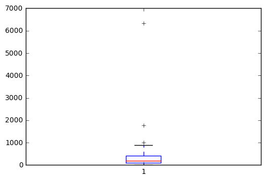

```python
plt.boxplot(paid_category2['Total Interactions']);
```

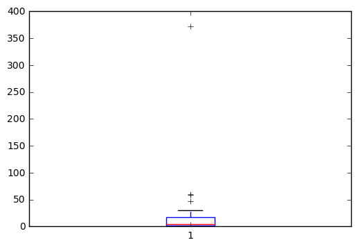

```python
plt.boxplot(paid_category2['comment']);
```

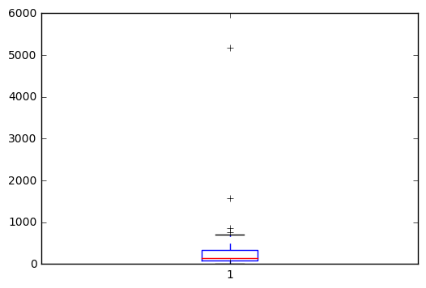

```python
plt.boxplot(paid_category2['like']);
```

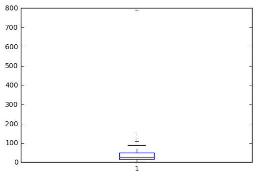

```python
plt.boxplot(paid_category2['share']);
```

**Видны несколько выбросов**

Вероятные причины:

1. вирусный эффект
2. поощрение действий пользователей, например конкурс с призами

Вирусный эффект более вероятен, т.к. наблюдается выброс по всем показателям. Поощрение действий пользователей скорее приведет к выбросу только по поощряемому действию.

Без аномалий по 'Total Interactions' популярный сегмент продолжает лидировать, но уже без двукратного превышения всех показателей

```python
df[df['Total Interactions']< 1000].groupby(['Paid', 'Category'])[popular].agg(['mean', 'count'])
```

| Paid | Category | comment mean | like count | share mean | Total Interactions count | mean | count | mean | count |
| --- | --- | --- | --- | --- | --- | --- | --- | --- | --- |
| 0.0 | 1 | 4.322148 | 149 | 97.844595 | 148 | 16.593103 | 145 | 117.657718 | 149 |
| 2 | 7.291667 | 96 | 138.333333 | 96 | 24.739583 | 96 | 170.364583 | 96 |  |
| 3 | 5.000000 | 108 | 170.314815 | 108 | 30.583333 | 108 | 205.898148 | 108 |  |
| 1.0 | 1 | 6.531250 | 64 | 151.062500 | 64 | 18.718750 | 64 | 176.312500 | 64 |
| 2 | 7.827586 | 29 | 205.275862 | 29 | 32.448276 | 29 | 245.551724 | 29 |  |
| 3 | 4.536585 | 41 | 158.195122 | 41 | 27.463415 | 41 | 190.195122 | 41 |  |

Есть аномалии и в других сегментах

```python
df[df['Total Interactions']> 1000].groupby(['Paid', 'Category'])[popular].agg(['mean', 'count'])
```

| Paid | Category | comment mean | like count | share mean | Total Interactions count | mean | count | mean | count |
| --- | --- | --- | --- | --- | --- | --- | --- | --- | --- |
| 0.0 | 1 | 93.000000 | 2 | 1288.500000 | 2 | 173.500000 | 2 | 1555.0 | 2 |
| 2 | 26.000000 | 1 | 1505.000000 | 1 | 95.000000 | 1 | 1626.0 | 1 |  |
| 3 | 61.000000 | 4 | 1428.000000 | 4 | 113.000000 | 4 | 1602.0 | 4 |  |
| 1.0 | 2 | 163.333333 | 3 | 2534.333333 | 3 | 342.333333 | 3 | 3040.0 | 3 |
| 3 | 40.000000 | 2 | 1522.500000 | 2 | 113.000000 | 2 | 1675.5 | 2 |  |

# Вывод

**Исходные параметры (категория, платность и т.д.) влияют на показатели популярности, но не объясняют выдающиеся показатели. Выделяющаяся популярность отдельных объектов объясняется либо поощрением активности пользователей, либо, скорее всего, вирусным эффектом - причина которого в самом контенте, а не в параметрах его публикации.**